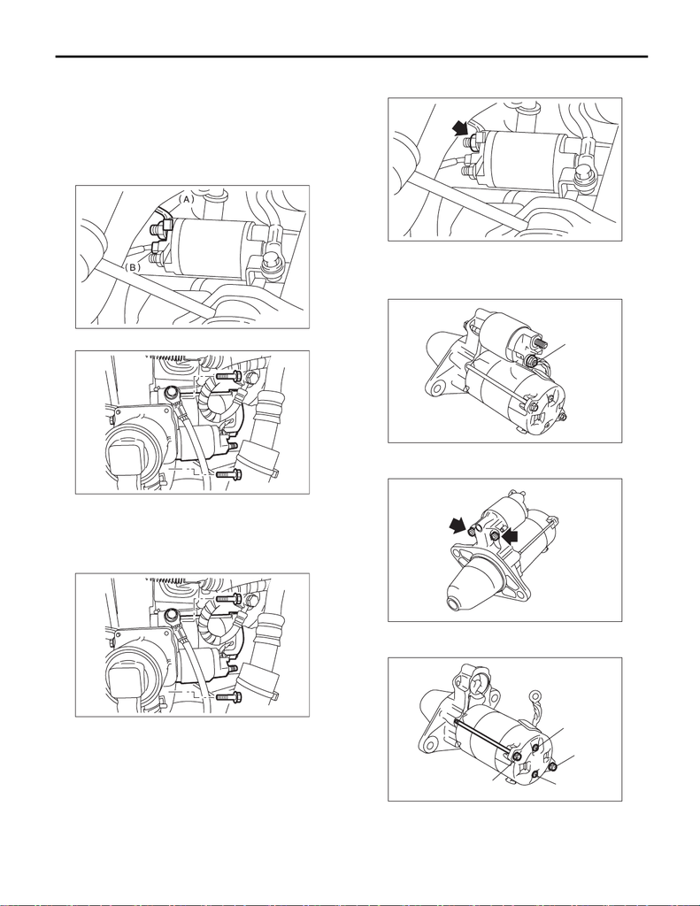

SC(STI)-7

Starter

STARTING/CHARGING SYSTEMS

2. Starter

A: REMOVAL

1) Disconnect the ground cable from battery.

2) Remove the intercooler. <Ref. to IN(STI)-13,

REMOVAL, Intercooler.>

3) Disconnect the connector (B) and terminal (A)

from starter.

4) Remove the starter from transmission.

B: INSTALLATION

Install in the reverse order of removal.

Tightening torque:

50 N·m (5.1 kgf-m, 36.9 ft-lb)

Tightening torque:

10 N·m (1.0 kgf-m, 7.4 ft-lb)

C: DISASSEMBLY

1) Disconnect cable from terminal M (A) of the

magnet switch assembly.

2) Remove the magnet switch assembly from the

starter housing assembly.

3) Remove through bolts (A) and screws (B) on

both sides, and remove the starter cover assembly.

SC-00006

SC-02151

SC-02151

SC-02474

SC-02208

(A)

SC-02209

SC-02210

(A)

(B)

(A)

(B)

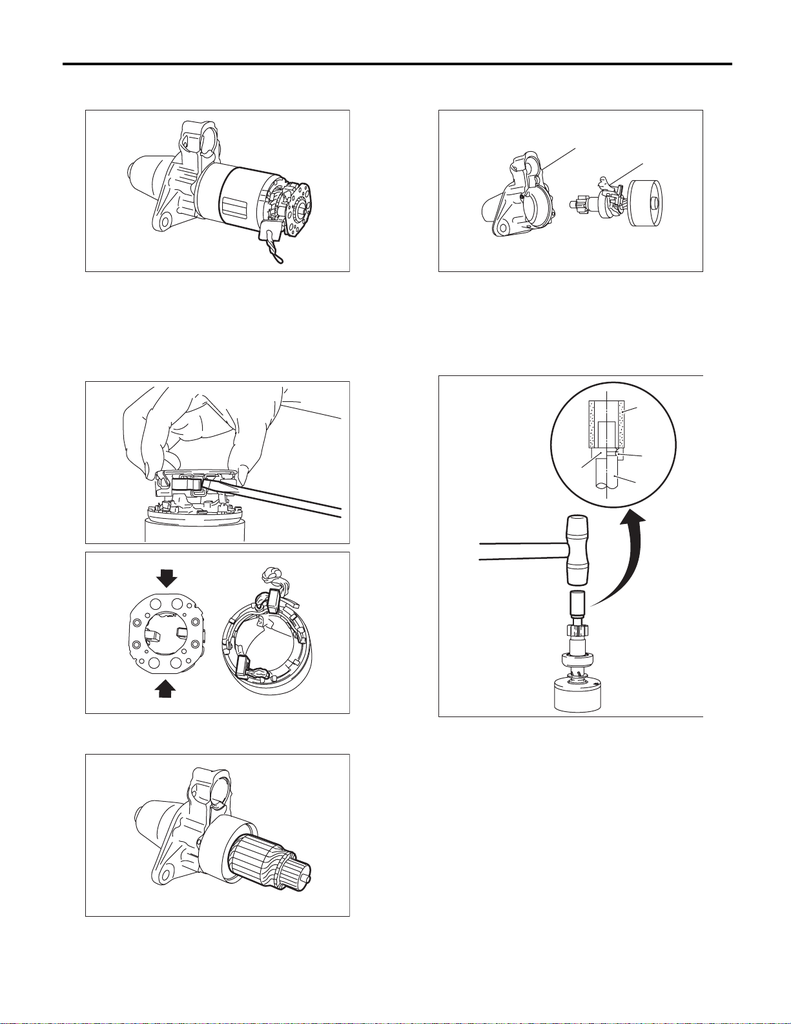

SC(STI)-8

Starter

STARTING/CHARGING SYSTEMS

4) Remove the yoke assembly and brush holder

assembly as a unit.

5) Remove the two brushes wired to the yoke as-

sembly, and separate the yoke assembly and the

brush holder assembly.

NOTE:

As shown in the figure, use a flat tip screwdriver,

etc. to hold the brush spring and remove the brush.

6) Remove the armature from the internal gear as-

sembly.

7) Remove the starter housing assembly (A) then

remove the shift lever (B).

8) Use the following procedures to remove the

overrunning clutch from the shaft.

(1) Use an appropriate tool (such as a fit socket

wrench), and remove the stopper from snap

ring by lightly tapping the stopper with a plastic

hammer.

SC-02211

SC-02220

SC-02212

SC-02213

(A) Appropriate tool

(B) Snap ring

(C) Shaft

(D) Stopper

(A)

(B)

SC-02214

(A)

(B)

(C)

(D)

SC-02216

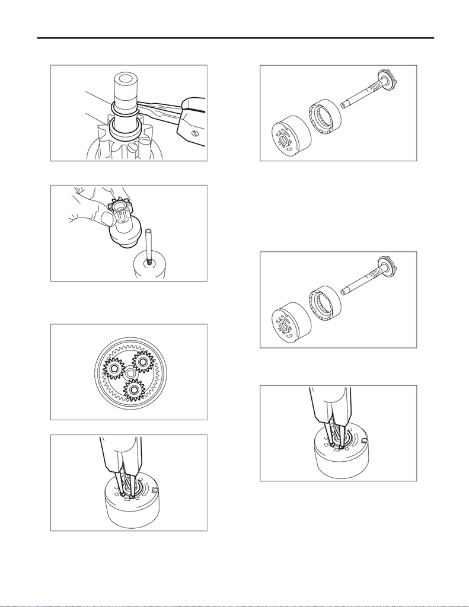

SC(STI)-9

Starter

STARTING/CHARGING SYSTEMS

(2) Remove snap ring (A) from the shaft, and

remove stopper (B).

(3) Remove the overrunning clutch from the

shaft.

9) Use the following procedures to remove the

shaft.

(1) Remove the starter plate, and remove the

pinion gear.

(2) Remove the snap ring from the shaft.

(3) Remove the shaft from the internal gear as-

sembly.

D: ASSEMBLY

1) Use the following procedures to install the shaft.

(1) Apply grease to the shaft sliding surfaces of

the internal gear assembly.

Grease:

DENSO HL50

(2) Assemble the shaft to the internal gear as-

sembly.

(3) Install the snap ring to shaft.

NOTE:

Use new snap rings.

(4) Apply grease to the pinion gear attachment

area.

Grease:

DENSO HL50

(5) Attach the pinion gear to the pin.

SC-02134

(A)

(B)

SC-02217

SC-02215

SC-02218

SC-02219

SC-02219

SC-02218

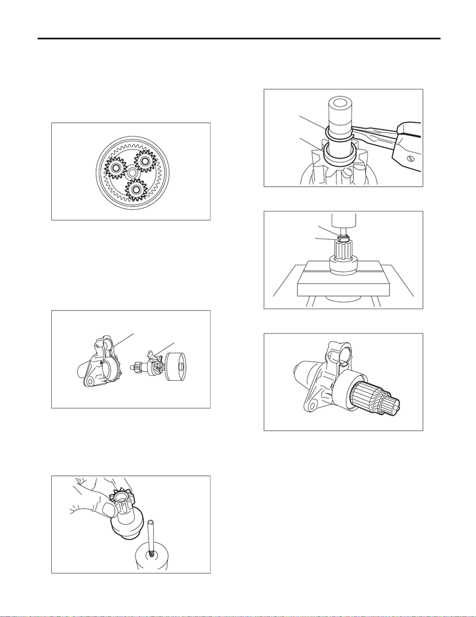

SC(STI)-10

Starter

STARTING/CHARGING SYSTEMS

(6) Apply grease to the pinion gear, internal

gear assembly, and on top of the shaft pin.

NOTE:

• Apply grease so that it contacts each gear.

• Be careful not to allow dirt to get in.

Grease:

DENSO HL50

(7) Install the starter plate.

2) Assemble the overrunning clutch and shift lever

(B) to the starter housing (A) as a unit.

NOTE:

Apply grease to the contact portion of the shift le-

ver.

Grease:

DENSO HL50

3) Assemble the overrunning clutch as follows:

(1) Apply grease to the spline portion of the

shaft.

Grease:

DENSO HL50

(2) Install the overrunning clutch to shaft.

(3) Pass stopper (B) through the shaft, and at-

tach snap ring (A).

NOTE:

Use new snap rings.

(4) Using a press, pressure fit stopper (B) into

snap ring (A).

4) Install the armature to the internal gear assem-

bly.

SC-02215

(A)

(B)

SC-02214

SC-02217

SC-02134

(A)

(B)

SC-00068

(A)

(B)

SC-02213

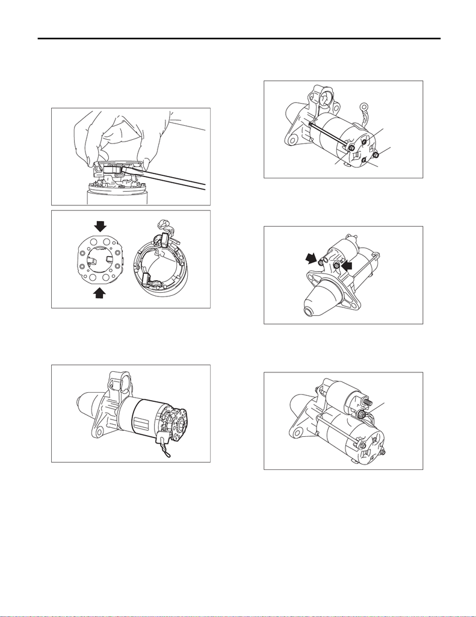

SC(STI)-11

Starter

STARTING/CHARGING SYSTEMS

5) Attach the two brushes wired to the yoke assem-

bly to the brush holder assembly.

NOTE:

As shown in the figure, use a flat tip screwdriver,

etc. to hold the brush spring and insert the brush

while being careful not to damage the brush.

6) Install the yoke assembly and brush holder as-

sembly as a single unit to the armature.

NOTE:

Spread the brush with your fingers, being careful

not to damage the brush.

7) Install starter cover assembly to the brush holder

assembly with screws (B).

Tightening torque:

1.4 N·m (0.1 kgf-m, 1.0 ft-lb)

8) Tighten the through bolts (A) on both sides.

Tightening torque:

6 N·m (0.6 kgf-m, 4.4 ft-lb)

9) Attach the magnet switch assembly to the starter

housing assembly.

Tightening torque:

7.5 N·m (0.8 kgf-m, 5.5 ft-lb)

10) Connect terminal M (A) to magnet switch as-

sembly.

Tightening torque:

10 N·m (1.0 kgf-m, 7.4 ft-lb)

SC-02220

SC-02212

SC-02211

SC-02210

(A)

(B)

(A)

(B)

SC-02209

SC-02208

(A)

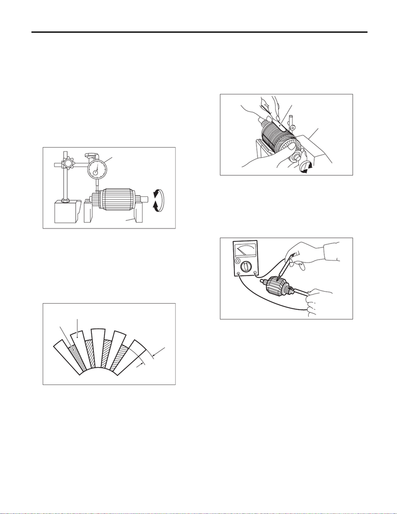

SC(STI)-12

Starter

STARTING/CHARGING SYSTEMS

E: INSPECTION

1. ARMATURE

1) Check the commutator for signs of seizure or

stepped wear caused by roughness of the surface.

If there is light wear, use sandpaper to repair.

2) Check for runout on the commutator. If exces-

sive, replace the armature.

Commutator runout:

Standard

0.05 mm (0.0020 in)

Limit

0.10 mm (0.0039 in)

3) Check the depth of the segment mold. If it is not

within the standard, replace the armature.

Depth of segment mold:

Standard

0.5 mm (0.020 in)

4) Place the armature on the growler tester to

check for short circuits. While slowly turning the ar-

mature, support the steel sheet for the armature

core. If the circuit of the armature is shorted, the

steel sheet will vibrate, causing it to move towards

the core. When the steel sheet has moved or vi-

brated, replace the armature.

5) Use a circuit tester to touch the probe of one side

to the commutator segment, and the other probe to

the shaft. If there is continuity, replace the arma-

ture.

2. YOKE

Make sure that the pole is set at the predetermined

position.

3. OVERRUNNING CLUTCH

Check that there is no wear or damage to the piston

teeth. Replace the overrunning clutch if it is dam-

aged.

Check that it rotates smoothly when rotated in the

correct direction (counterclockwise) and does not

return to the other direction. Replace the overrun-

ning clutch if any fault is found.

CAUTION:

To prevent spilling of grease, do not clean the

overrunning clutch with oil.

(A) Dial gauge

(B) V-block

(A) Depth of mold

(B) Segment

(C) Mold

SC-00021

(A)

(B)

(C)

(B)

(A)

SC-00022

(A) Steel sheet

(B) Growler tester

(A)

(B)

SC-00023

SC-00024

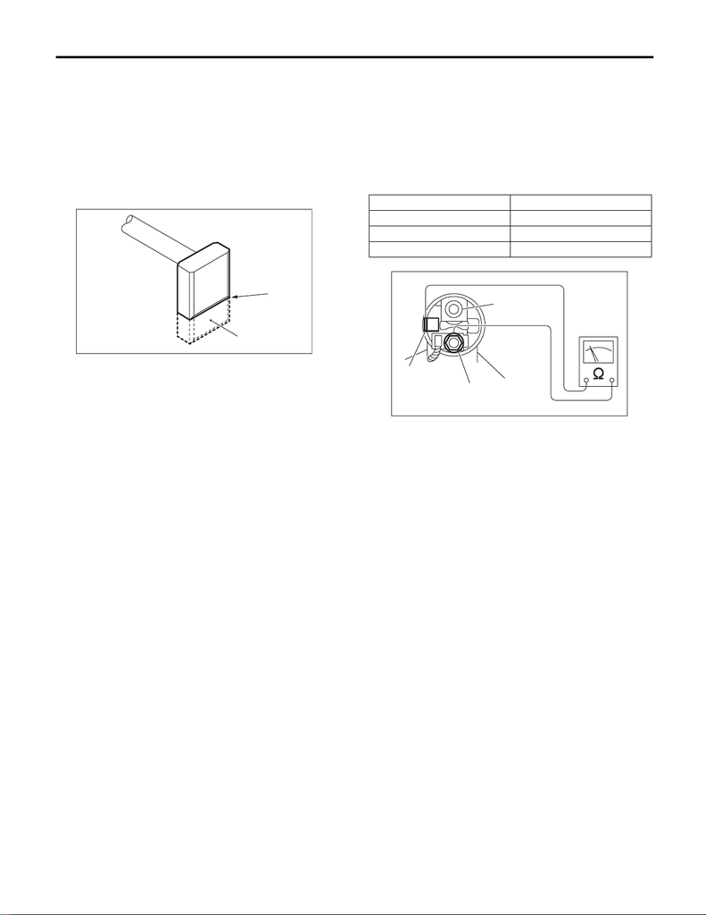

SC(STI)-13

Starter

STARTING/CHARGING SYSTEMS

4. BRUSH AND BRUSH HOLDER

1) Measure the length of the brush. Replace if it ex-

ceeds service limits or there is abnormal wear or

cracks.

Brush length:

Standard

12.3 mm (0.484 in)

Limit

7.0 mm (0.276 in)

2) Check that the brush moves smoothly in the

brush holder.

3) Measure the brush spring force with a spring

scale. Replace the brush holder if below the service

limit.

Brush spring force:

Standard

15.9 — 19.5 N (1.62 — 1.99 kgf, 3.57 — 4.38

lbf) (When new)

Limit

2.5 N (0.25 kgf, 0.56 lbf)

5. SWITCH ASSEMBLY

Using a circuit tester (set to “ohm”), check that

there is continuity between terminals S and M, and

between terminal S and ground.

Also check to be sure there is no continuity be-

tween M terminal and B.

Resistance between switch assembly termi-

nals:

(A) Service limit line

(B) Brush

SC-00102

(A)

(B)

Terminals Standard

S — M 1 Ω or less

S — Ground 1 Ω or less

M — B 1 MΩ or more

(A) S terminal

(B) M terminal

(C) B terminal

SC-00181

(A)

(B)

(C)

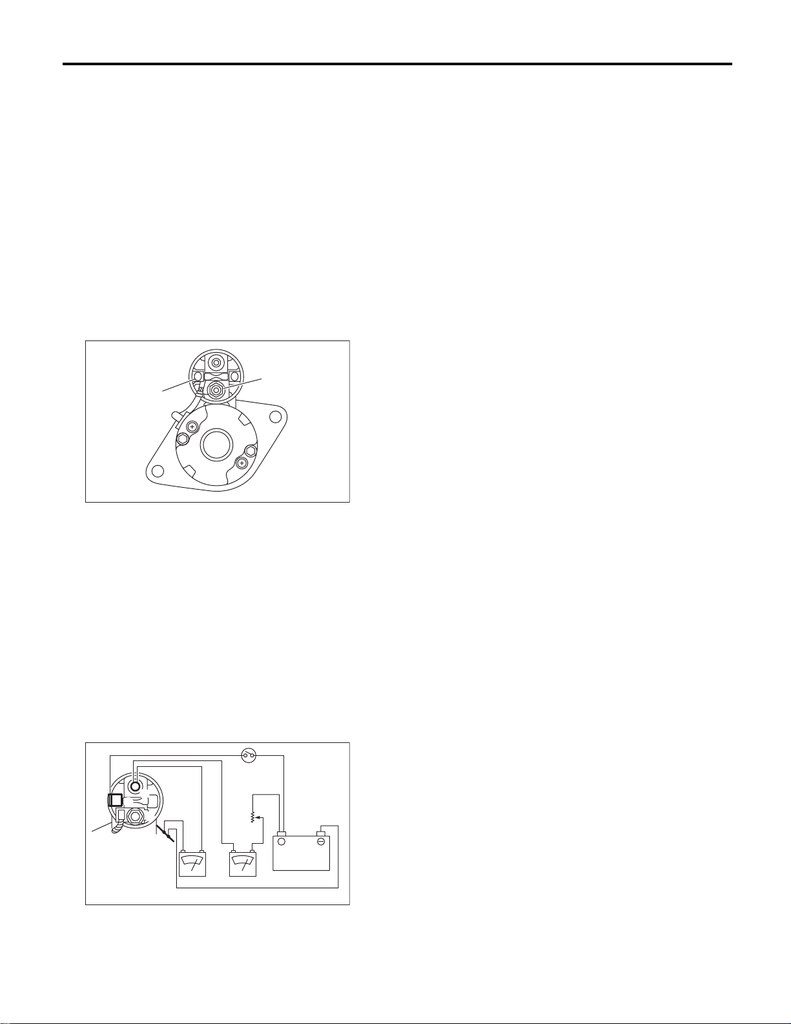

SC(STI)-14

Starter

STARTING/CHARGING SYSTEMS

6. SWITCH ASSEMBLY OPERATION

1) Using a lead wire, connect the terminal S of

switch assembly to positive terminal of battery, and

starter body to ground terminal of battery. The pin-

ion should be forced endwise on shaft.

NOTE:

With the pinion forced endwise on shaft, starter mo-

tor can sometimes rotate because current flows,

through pull-in coil, to motor. This is not a problem.

2) Disconnect the connector from terminal M. Then

using a lead wire, connect the positive terminal of

battery and terminal M, and ground terminal to

starter body.

In this test set up, the pinion should return to its

original position even when it is pulled out with a

screwdriver.

7. PERFORMANCE TEST

The starter should be submitted to performance

tests whenever it has been overhauled, to assure

its satisfactory performance when installed on the

engine.

Three performance tests, no-load test, load test,

and lock test, are presented here; however, if the

load test and lock test cannot be performed, carry

out at least the no-load test.

For these performance tests, use the circuit shown

in figure.

1) Adjust the variable resistance with the switch on

until the voltage is 11 V, and read the value dis-

played by the ammeter to measure starter speed.

Compare these values with the standard.

No-load test (standard):

Voltage/Current

Max. 11 V/90 A or less

Rotating speed

2,860 rpm or more

2) Apply the specified braking torque to starter. The

condition is normal if the current draw and starter

speed are within standard.

Load test (standard):

Voltage/Load

8 V/9.3 N·m (0.9 kgf-m, 6.9 ft-lb) or more

Current/Speed

280 A/860 rpm or more

3) With the starter stalled, or not rotating, measure

the torque developed and current draw when the

voltage is adjusted to standard voltage.

Lock test (standard):

Voltage/Current

4 V/515 A or less

Torque

16 N·m (1.6 kgf-m, 11.8 ft-lb) or more

8. OTHER INSPECTIONS

Check that the starter does not have deformation,

cracks and any other damage.

(A) Terminal S

(B) Terminal M

(A) Variable resistance

(B) Magnet switch

(C) Starter body

SC-00175

(A)

(B)

(A)

(B)

(C)

12V

+

AV

B

S

M

SC-00077